# Symboliskt perspektiv på varumärken

SKOC26: Varumärkeskommunikation VT25  
Moment 2: Varumärkning av konsumentprodukter

nils.holmberg@iko.lu.se

## Presentation

- Kommunikation är…
  - en vetenskap om
  - ett verktyg för
- att påverka attityder
- kognition, beteenden
- mätmetoder, experiment

## Kurslitteratur

Östberg and Bengtsson (2018)

[figure not shown]

Elliott et al. (2015)

[figure not shown]

Holt (2004)

## Examinationer

**Case-diskussion 2**

- symboliska och funktionella varumärkesstrategier
- varumärken och konsumenters identitetsskapande
- konsumtionsgemenskaper
- teorier om ikoniska varumärken

**Hemtenta**

- corporate branding (moment 1)
- symboliskt perspektiv på varumärken (moment 2)
- varumärken som styrning och utveckling (moment 3)
- hållbarhetsutmaningar

## Översikt

**Konsumentperspektiv**

- Östberg and Bengtsson (2018)
  - 2. Konsumentforskningens framväxt
  - 3. Märkesförfattare
  - 4. Märkeskulturer
  - 5. Individen och märken
  - 6. Konsumtionsstammar och märkesgemenskaper
  - 7. Märkesmotstånd

**Ledningsperspektiv**

- Elliott et al. (2015)
  - 3. The Symbolic Meaning of Brands
  - The Postmodern Consumer
  - Self-Symbolic Consumption
  - Social-Symbolic Consumption
- Holt (2004)
  - 1. What Is an Iconic Brand?
  - 2. How Is Cultural Branding Different?

## 1. Introduction

- **Economic/Functional Perspective** – Patagonia emphasizes **durability and sustainability**, positioning its products as long-term investments that reduce waste.
- **Psychological/Consumer Behavior Perspective** – The brand appeals to **eco-conscious consumers** by aligning with values of environmental responsibility and ethical consumption.
- **Corporate/Strategic Perspective** – Patagonia integrates **activism into its branding**, using initiatives like “1% for the Planet” to strengthen its **brand loyalty and differentiation**.
- **Socio-Cultural Perspective** – The brand fosters a **community-driven movement**, engaging with outdoor enthusiasts, climate activists, and ethical fashion advocates.
- **Symbolic Perspective** – Wearing Patagonia **signals symbolic commitment to sustainability**, making it a **status symbol for ethical consumers** and environmentally aware professionals.

## 2. Konsumentforskningens framväxt

- Fokus skiftar från enbart köpbeslut till bredare konsumentbeteende.
- Konsumtion ses som en del av vardagslivet och sociala sammanhang.
- Identifiering av emotionella och symboliska aspekter av konsumtion.
- Konsumenten är inte enbart rationell utan påverkad av kultur och identitet.
- Marknadsförare anpassar strategier för att spegla konsumenters värderingar.
- Konsumentperspektiv

Östberg and Bengtsson (2018)

## Tolkande konsumentforskning

#### 2. Konsumentforskningens framväxt

- Kvalitativa metoder för att förstå konsumentens upplevelse och meningsskapande.
- Fokus på subjektiva tolkningar och narrativ snarare än kvantitativa data.
- Konsumtion analyseras genom sociokulturella och semiotiska perspektiv.
- Betonar vikten av storytelling och myter i varumärkesbyggande.
- Hjälper företag att förstå djupare kundmotiv och emotionell koppling.
- Exempel: Starbucks skapar en upplevelse bortom kaffe genom ritualer, symbolik och gemenskap.

## Konsumtion + produktion = prosumtion

#### 2. Konsumentforskningens framväxt

- Konsumenter blir medskapare av varumärkens mening och värde.
- Sociala medier gör att kunder aktivt kan påverka varumärkesberättelser.
- UGC (User-Generated Content) skapar trovärdighet och autenticitet.
- Varumärken interagerar direkt med konsumenter för att bygga relationer.
- Prosumtion utmanar traditionella maktförhållanden mellan företag och kund.
- Exempel: Nike låter kunder designa egna skor via Nike By You, vilket ger dem en aktiv roll i produktionsprocessen.

## 3. Märkesförfattare

- Varumärken skapas av flera aktörer: företag, konsumenter, medier.
- Reklam och storytelling hjälper till att forma ett märkes identitet.
- Konsumenter kan omtolka och ge egna betydelser till varumärken.
- Sociala medier ger användare makt att delta i varumärkesberättelsen.
- Varumärkesmening är alltid under förhandling mellan olika författare.

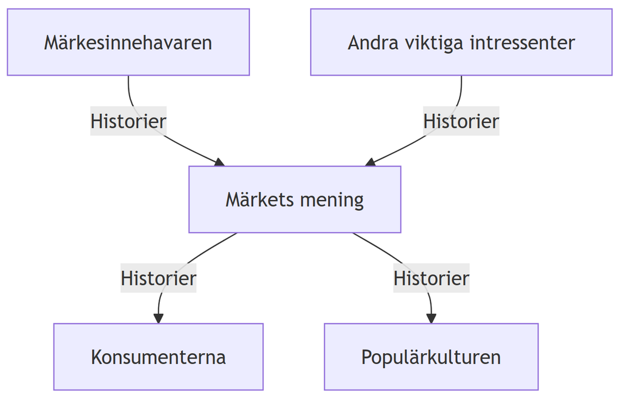

## 4. Märkeskulturer

- Branding ses som en del av konsumtionskulturer och samhällsstrukturer.
- Konsumenter tolkar och omskapar varumärken inom sina kulturella sammanhang.
- Skiftet från transaktionsbaserad marknadsföring till upplevelsebaserad branding.
- Varumärkens identitet formas genom interaktioner mellan företag och konsumenter.

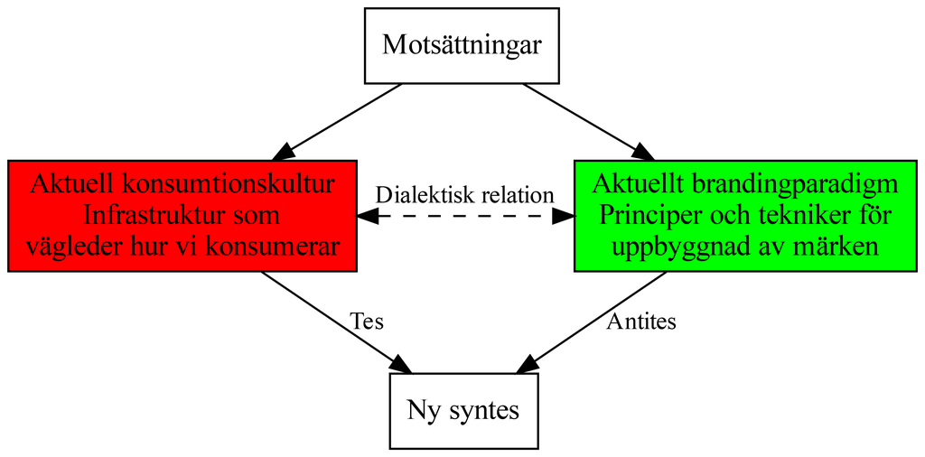

## 5. Individen och märken

- Varumärken hjälper individer att uttrycka sin identitet.
- Konsumtion blir ett sätt att spegla personlighet och värderingar.
- Identitetsskapande genom varumärken kan förändras över tid.
- Sociala grupper och tillhörighet formar hur vi använder varumärken.
- Digitala medier gör att individer kan bygga personliga varumärken online.
- Konsumentperspektiv

Östberg and Bengtsson (2018)

## Märken och meningsskapande

#### 5. Individen och märken

- Varumärken fungerar som kulturella symboler med flera betydelser.
- Konsumenter tolkar varumärken genom sina egna erfarenheter.
- Marknadsföringens narrativ kan styra hur varumärken uppfattas.
- Symbolisk konsumtion hjälper individer att skapa mening i sin vardag.
- Märken kopplas ofta till minnen, känslor och livshistorier.
- Exempel: Levi’s jeans symboliserar både amerikansk frihet och personligt självuttryck, men kan också tolkas olika beroende på generation och kultur.

## Märkesrelationer

#### 5. Individen och märken

- Konsumenter utvecklar emotionella band till varumärken.
- Varumärkeslojalitet bygger på förtroende och positiva erfarenheter.
- Märken kan ses som “vänner” eller “fiender” beroende på upplevelser.
- Relationer till varumärken kan vara kortsiktiga eller livslånga.
- Sociala medier förstärker interaktionen mellan konsumenter och varumärken.
- Exempel: Apple skapar starka märkesrelationer genom ekosystemet av produkter och exklusiv community, medan vissa användare aktivt undviker märket på grund av slutna system.

## 6. Konsumtionsstammar och märkesgemenskaper

- Gemenskap handlar om tillhörighet – grupper delar normer, värderingar och symboler.
- Varumärken kan skapa emotionella band mellan konsumenter genom delade erfarenheter.
- Digitala plattformar möjliggör nya former av gemenskaper bortom fysiska gränser.
- Skillnad mellan praktiska gemenskaper (funktionella) och symboliska gemenskaper (identitetsskapande).
- Exempel: Harley-Davidson och Apple har byggt starka varumärkesgemenskaper kring delad kultur.

Östberg and Bengtsson (2018)

## Från traditionella gemenskaper till postmoderna stammar

#### 6. Konsumtionsstammar och märkesgemenskaper

- Traditionella gemenskaper baseras på **geografi, familj och långsiktiga relationer.**
- **Postmoderna konsumtionsstammar** är flexibla, självvalda och baserade på intressen.
- Konsumenter deltar **temporärt i olika stammar** beroende på livsstil och kontext.
- Varumärken fungerar som **samlande symboler** för identitet och gemensam kultur.
- **Exempel:** Sneaker-kulturen och gaming-communityn bygger på postmoderna stammar.

## **Olika typer av konsumtionsstammar**

#### 6. Konsumtionsstammar och märkesgemenskaper

- **Subkulturer**: Avgränsade grupper med egna normer och värderingar.
- **Brand communities**: Gemenskaper där varumärket står i centrum för interaktionen.
- **Tribes**: Lösa och dynamiska nätverk där varumärken används som symboler.
- **Fandoms**: Intensiva, engagerade grupper kring en produkt, ex. Star Wars-fans.
- **Exempel:** Hiphop-mode och motorcykelkultur representerar olika konsumtionsstammar.

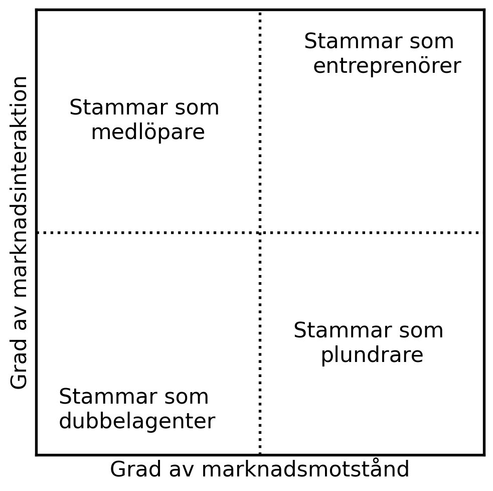

## **Finns det egentligen märkesgemenskaper och är de i så fall meningsfulla?**

#### 6. Konsumtionsstammar och märkesgemenskaper

- Kritisk fråga: Är varumärkesgemenskaper genuina eller marknadsstyrda fenomen?
- **Kommersialisering kan urvattna autentiska gemenskaper** och skapa motreaktioner.
- **Konsumenter formar egna tolkningar** och kan utmana företags narrativ.
- Märkesgemenskaper ger mening och identitet, men deras styrka varierar.
- **Exempel:** Nike’s användning av storytelling för att skapa en global community.

## 7. Märkesmotstånd

- Konsumenter kan känna sig fast i varumärkessystemet, med begränsade alternativ.
- Varumärken blir så dominerande att de uppfattas som oundvikliga i vardagen.
- Företagsmakten över konsumtionsval kan skapa en känsla av förlust av autonomi.
- Många försöker bryta sig ur märkesfängelset, men finner få praktiska alternativ.
- Exempel: Stora teknikföretags ekosystem (Apple, Google) som låser in konsumenter.

Östberg and Bengtsson (2018)

## **Konsumenters märkesundvikande**

#### 7. Märkesmotstånd

- Vissa konsumenter väljer aktivt att **undvika eller ignorera varumärken**.
- Orsaker kan vara **etiska, ekonomiska eller personliga övertygelser**.
- Märkesundvikande kan innebära att välja **generiska produkter eller lokala alternativ**.
- Minimalism och anti-konsumtionsrörelser främjar **avståndstagande från branding**.
- Exempel: Fairphone som ett alternativ till mainstream teknikföretag.

## **Culture jamming eller populärkulturellt märkesmotstånd**

#### 7. Märkesmotstånd

- *Culture jamming* innebär att **ifrågasätta och parodiera kommersiella budskap**.
- Aktivister hackar reklamer och varumärkesbilder för att **vända budskapet emot företagen**.
- Guerillamarknadsföring kan användas både av företag och aktivistgrupper.
- Populärkulturellt märkesmotstånd kan spridas genom **memes, konst och digitala kampanjer**.
- Exempel: Adbusters kampanj mot konsumtionshets och *Buy Nothing Day*.

## Tillbakablick

- Östberg and Bengtsson (2018)
  - 2. Konsumentforskningens framväxt
  - 3. Märkesförfattare
  - 4. Märkeskulturer
  - 5. Individen och märken
  - 6. Konsumtionsstammar och märkesgemenskaper
  - 7. Märkesmotstånd
- Konsumentperspektiv
- Vad saknas?
  - Digitala perspektiv
  - Tiktok
  - Influencer marketing
  - Metaverse
  - Artificial intelligence
  - Sustainability communication
  - Brand activism

## Tiktok

#### Digital Strategies in Brand Communication

- **Democratization of Branding** – Anyone can create viral brand narratives, shifting control from corporations to users.
- **Symbolic Play & Remix Culture** – Users reinterpret brand messages through trends, memes, and challenges.
- **Algorithm-Driven Virality** – Brand visibility depends on engagement, not traditional marketing budgets.
- **Authenticity vs. Curation** – Raw, user-generated content disrupts polished brand storytelling.
- **Short-Lived Symbolism** – Brand meanings evolve rapidly, requiring constant adaptation to trends.

## Influencer marketing

#### Digital Strategies in Brand Communication

- **Humanizing Brands** – Influencers act as cultural intermediaries, making brands feel more personal and relatable.
- **From Corporate Control to Co-Creation** – Consumers now co-create brand meanings, disrupting top-down messaging.
- **Authenticity vs. Commercialization** – Influencers balance personal credibility with sponsored content, shaping trust.
- **Symbolic Consumption in Micro-Communities** – Niche influencers redefine brand symbolism for specific subcultures.
- **Algorithmic Gatekeeping** – Platform algorithms, rather than traditional media, now dictate brand visibility and influence.

## Artificial intelligence

#### Digital Strategies in Brand Communication

- **Hyper-Personalization** – Predictive AI refines brand messaging by analyzing consumer data, enhancing targeted communication.
- **AI-Generated Content** – Generative AI disrupts traditional branding by autonomously creating ads, visuals, and even product designs.
- **Erosion of Brand Authenticity** – AI-driven branding risks losing human creativity and emotional connection, making brands feel less personal.
- **Symbolic Branding at Scale** – AI enables brands to craft personalized symbols and narratives, adapting them dynamically for different audiences.
- **Challenges to Brand Control** – Consumers and AI tools can now co-create and modify brand meanings, shifting authority away from companies.

## Metaverse

#### Digital Strategies in Brand Communication

- **Virtual Brand Ownership** – NFTs allow consumers to “own” digital brand assets, deepening brand engagement.
- **Expanded Brand Spaces** – The metaverse creates immersive brand experiences beyond physical products and ads.
- **Decentralized Branding** – Consumers gain more control over brand narratives through blockchain-based assets.
- **Symbolic Capital in Digital Worlds** – Virtual goods and NFTs act as new status symbols, redefining brand value.
- **From Exclusivity to Accessibility** – NFTs promise scarcity, yet metaverse spaces foster open, participatory brand interactions.

## Sustainability communication

#### Digital Strategies in Brand Communication

- **Storytelling Through Social Media** – Brands use platforms like Instagram and TikTok to share sustainability efforts through engaging narratives.
- **Blockchain & Transparency** – Digital tools verify ethical sourcing and sustainability claims (e.g., blockchain for supply chain tracking).
- **AI & Data-Driven Personalization** – AI helps tailor sustainability messages to consumer values, increasing engagement and trust.

[figure not shown]

## Brand activism

#### Digital Strategies in Brand Communication

- **Purpose-Driven Campaigns** – Brands leverage digital platforms to advocate for social, environmental, or political causes (e.g., Nike’s Colin Kaepernick campaign).
- **Hashtag Movements & Viral Advocacy** – Social media hashtags amplify brand activism messages, mobilizing communities (e.g., #StopHateForProfit).
- **Consumer Co-Creation & Engagement** – Digital tools empower consumers to contribute to brand-led social initiatives (e.g., Patagonia’s activism platform).
- **Risk & Backlash Management** – Brands must navigate online criticism and ensure authenticity to maintain credibility in digital activism.

## 3. The Symbolic Meaning of Brands

- The postmodern consumer and symbolic meaning 51
- The postmodern consumer and identity 53
- Identity and self-symbolic consumption 55
- Symbolic meaning, advertising, and brands 57
- Identity and social-symbolic consumption
- Some implications for brand strategy
- Ledningsperspektiv

[figure not shown]

Elliott et al. (2015)

## **The Postmodern Consumer**

#### 3. The Symbolic Meaning of Brands

- The postmodern consumer is fragmented, engaging with multiple identities based on context.
- Consumption is not just about utility but about constructing personal narratives.
- Consumers seek experiences, emotions, and meanings rather than just products.
- Brand loyalty is fluid, as consumers mix and match brands to express themselves.
- Digital culture accelerates the shift from passive consumption to co-creation.

## **Identity and Self-Symbolic Consumption**

#### 3. The Symbolic Meaning of Brands

- Brands function as **symbols of self-expression** and personal identity.
- Consumers choose brands that reflect their **aspirations, values, and self-image**.
- Brand attachment is stronger when a brand aligns with **self-concept and emotions**.
- Luxury and lifestyle brands often serve as **identity markers**.
- Changes in self-identity over time lead to shifts in brand preferences.

## **Identity and Social-Symbolic Consumption**

#### 3. The Symbolic Meaning of Brands

- Brands communicate **social identity**, signaling group membership and social status.
- Consumption patterns reflect **cultural norms, class distinctions, and peer influence**.
- Consumers use brands to create social bonds or distinguish themselves from others.
- Subcultures and brand communities (e.g., sneaker culture, gaming) reinforce group identity.
- Ethical and sustainable brands serve as **moral identity symbols** for conscious consumers.

## **Some Implications for Brand Strategy**

#### 3. The Symbolic Meaning of Brands

- Brands must create **meaningful narratives** that resonate with consumer identities.
- Understanding **cultural and social contexts** helps brands stay relevant.
- Emotional connections are key—functional benefits alone are not enough.
- Co-creation with consumers strengthens brand authenticity and loyalty.
- Successful brands adapt to **evolving social trends** while maintaining core identity.

## 2. How Is Cultural Branding Different?

- What Is an Iconic Brand?
- From Mind-Share Branding to Cultural Branding
- From Emotional Branding to Cultural Branding
- From Viral Branding to Cultural Branding
- The Path to Cultural Branding

[figure not shown]

Holt (2004)

## **What Is an Iconic Brand?**

#### 2. How Is Cultural Branding Different?

- **Iconic brands** go beyond functional or emotional appeals; they represent cultural ideals.
- These brands become **symbols of identity** for consumers and are embedded in societal narratives.
- They often emerge during **cultural tensions** and provide solutions to identity conflicts.
- Successful iconic brands must continuously **adapt to cultural shifts** to stay relevant.
- Examples include **Nike (achievement), Harley-Davidson (freedom), and Apple (creativity).**

## **From Mind-Share Branding to Cultural Branding**

#### 2. How Is Cultural Branding Different?

- **Mind-share branding** focuses on owning a specific position in consumers’ minds through repetition.
- **Cultural branding**, in contrast, embeds brands into **cultural myths and collective storytelling**.
- Consumers engage with brands **not just as products, but as cultural resources**.
- Unlike mind-share branding, **cultural branding evolves organically** rather than through static positioning.
- Example: **Coca-Cola’s identity as a symbol of American optimism, shaped by ads and cultural moments**.

## **From Emotional Branding to Cultural Branding**

#### 2. How Is Cultural Branding Different?

- Emotional branding **creates deep affective connections** between consumers and brands.
- Cultural branding is **not just about emotions, but about meaning**, drawing from societal issues.
- Emotional branding relies on **individual experiences**, whereas cultural branding appeals to **shared narratives**.
- **Cultural brands resonate because they reflect and influence societal changes**.
- Example: **Nike’s “Just Do It” campaign is emotional, but its role in activism (e.g., Colin Kaepernick) is cultural**.

## Next steps

- **Workshop hemtenta, feb 12**
- **Föreläsning digitala strategier, feb 18**
- **Examination case 2, feb 24-25**
- **References**

Elliott, Richard H, Richard Rosenbaum-Elliott, Larry Percy, and Simon Pervan. 2015. *Strategic Brand Management*. Oxford University Press, USA.

Holt, Douglas B. 2004. “How Brands Become Icons: The Principles of Cultural Branding.” *Harvard Business Review Press*.

Östberg, Jacob, and Anders Bengtsson. 2018. *Märken Och människor: Om Marknadssymboler Som Kulturella Resurser*. Studentlitteratur.